# Introduction to Shiny

Session 4: *Reactivity and the user session*

Danny Smith

# Housekeeping

## Course outline

1. Introduction to Shiny
2. Shiny UI - layout, styling and theming
3. Shiny UI - dynamic UI and extensions
4. *Reactivity and the user session*
5. Shiny modules, working with data
6. Application structure and workflow

## Recap

### Last Session

3. *Shiny UI - dynamic UI and extensions*
- Homework
- Readings
- Questions?

## Resources

#### Session materials

[GitHub repo](https://github.com/gorcha/r_shiny_intro_data)

#### Online resources

*Nothing new this session*

## This session

- Reactivity revisited
  - Reactive graph in practice
  - Reactive building blocks
  - Debugging reactivity
- Shiny `session` object
- Bookmarking

# Reactivity revisited

## Reactive components

**Reactive source**

A source of data that can tell dependent objects that they need to re-execute. Usually a user input from the browser.

**Reactive endpoint**

An expression performing an action that will re-execute when its dependencies change. Actions include rendering content in the browser.

**Reactive conductor**

An expression inside the reactive graph, that can use and be used by other reactive components. Often used to encapsulate code used in multiple places, like a function.

## Reactive graph

- Graph of *reactive dependencies*
  - What outputs depend on what inputs?
  - Other reactive components (e.g. reactive expressions)
  - Determines when code is executed and in what order
- Graph of *reactive components*
  - Connected in the dependency graph
  - Shiny keeps track of *reactive state* of each component
  - What components need to be executed?

## Reactive states

Reactive components can be in one of several states

**Ready**

Component has been executed and its value is cached pending access by a dependent

**Calculating**

Currently executing - waiting on dependencies to execute

**Invalidated**

Component has been invalidated and must be re-executed before use

**Invalidating**

Currently invalidating - waiting on dependents to invalidate

## Reactive computation

Reactive computation is a cycle of *execution* and *invalidation*

**Execution**

Invalidated reactive endpoints are executed, triggering execution of any invalidated dependencies. This phase produces outputs and runs observers.

**Invalidation**

Reactive sources change, invalidating any dependents. This phase starts when inputs and other sources change, and triggers the execution phase when complete.

# Reactive graph in practice

📝 session_04/reactive_graph.R

## Visualising the reactive graph

📦 [reactlog](https://rstudio.github.io/reactlog/)

- Visualise and explore the reactive graph of an application
- `reactlog_enable()`, Ctrl + F3 to view the graph
- Replay the log after closing with `reactlogShow()`

```r
library(shiny)

ui <- fixedPage()

server <- function(input, output, session) { }

reactlog::reactlog_enable()
shinyApp(ui, server)
```

## Execution begins

- Execute endpoints
  - All invalidated endpoints
  - Execution order is random
- Build relationships
  - Determine dependencies
  - Add dependencies to the graph

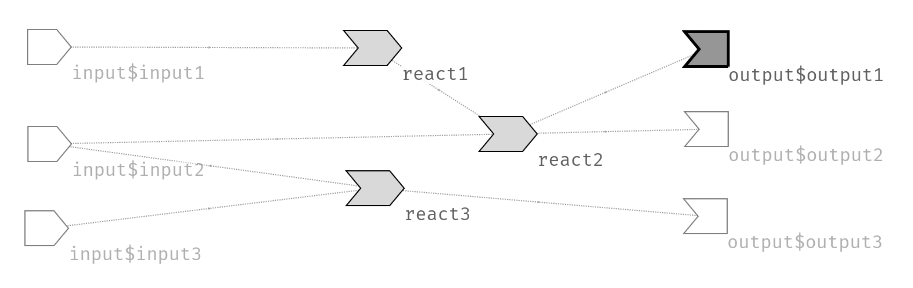

At the start of the session all components are *invalidated*

## Execution continues

- Execute dependencies
  - Only if *invalidated*
  - Follow the graph!
- Continue recursively
  - Determine dependencies
  - Execute one by one

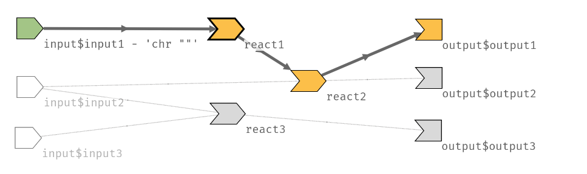

The execution phase *builds the dependency graph*

## Ready

- Execution is complete
  - Complete dependency graph
  - All components are *ready*

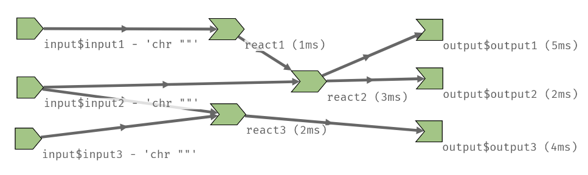

The reactive graph is complete, pending input changes

## Invalidation

- Inputs change
  - *Invalidate* dependents
  - Follow the graph!
- Remove relationships
  - The graph is *invalidated*
  - Dependencies may change

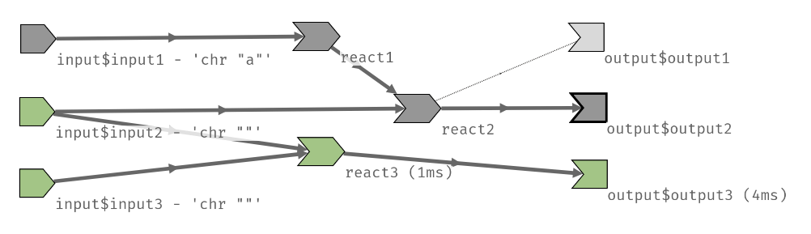

The invalidation phase *removes dependencies* from the graph

## Re-execution

- Re-execute invalidated endpoints
  - Execution order is random
  - Re-build dependency graph
- Re-execute dependencies
  - Only if *invalidated*
  - Continue recursively

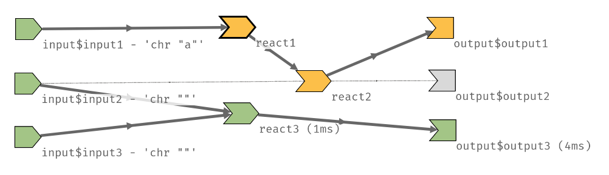

The execution phase *re-builds the dependency graph*

## Re-ready

- Re-execution is complete
  - Complete dependency graph
  - All components are *ready*

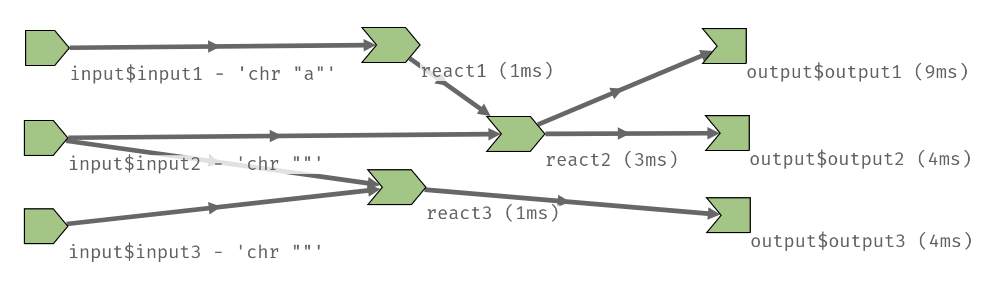

The cycle continues…

# Reactive building blocks

## Expressions and Observers

Expressions that are re-executed when their dependencies change

**Reactive expressions - `reactive()`**

*Reactive conductor* used in other reactives - create a calculated value

**Observers - `observe()`**

*Reactive endpoint* used for side effects - perform an action

**Events - `bindEvent()`**

Execute an expression or observer only when an event occurs

📝 session_04/reactive_observe.R

📝 session_04/reactive_event.R

## Reactive values

Create simple values that are *reactive sources*

- `reactiveVal()`
  - A single value
  - Use like a function
- `reactiveValues()`
  - Multiple values
  - Use like a list
- Update from the server

```r
server <- function(input, output, session) {
  input_text_change <- reactiveVal(0)
  input_change <- reactiveValues(a = 0, b = 0)

  observe({
    input_text_change(input_text_change() + 1)
    input_change$a <- input_change$a + 1
  }) |>
    bindEvent(input$text_a)

  observe({
    input_text_change(input_text_change() + 1)
    input_change$b <- input_change$b + 1
  }) |>
    bindEvent(input$text_b)
}
```

📝 session_04/reactive_values.R

## Isolation

Use reactive components without adding a dependency

- Use `isolate()`
  - Access reactive value or expression
  - Do not re-execute when reactive changes
- Avoid circular dependencies

```r
server <- function(input, output, session) {
  output$number_text <-  renderText({
    input$print

    isolate({
      paste0("The number is: ", input$number)
    })
  })

  number_change <- reactiveValues(count = 0)

  observe({
    input$number
    number_change$count <- isolate(number_change$count) + 1
  })
}
```

📝 session_04/reactive_isolate.R

## Timed invalidation

Invalidate reactive expression at regular intervals

- `invalidateLater()`
  - Invalidate a single expression
- `reactiveTimer()`
  - Reactive component
  - Use in multiple places
  - Synchronise!

```r
server <- function(input, output, session) {
  output$random_x <- renderText({
    invalidateLater(1000)
    runif(1)
  })

  my_timer <- reactiveTimer(500)

  output$random_y <- renderText({
    my_timer()
    runif(1)
  })

  output$random_z <- renderText({
    my_timer()
    runif(1)
  })
}
```

📝 session_04/reactive_timer.R

## Polling

Reactive data source that checks for changes at regular intervals

- `reactiveFileReader()`
  - File path and reader
  - Check most recent modified time
- `reactivePoll()`
  - Custom check function
  - Value function loads data
  - Use for external sources

```r
server <- function(input, output, session) {
  data_csv <- reactiveFileReader(
    1000,
    session,
    filePath = "data.csv",
    readFunc = read.csv
  )

  data_api <- reactivePoll(
    1000,
    session,
    checkFunc = function() api_last_modified(),
    valueFunc = function() api_data()
  )
}
```

## Outside the graph

Invalidating inputs in the server function is *outside the graph*

- `update*Input()` functions
- Changing reactive values
- Can reconnect the output side to the input side

**Be careful!**

- Easy to accidentally create circular dependencies
- Make sure you understand how the reactive graph is working if you’re doing fancy things

# Debugging reactivity

## In the console

Traditional R debugging methods

- Printing
  - Print to the console!
  - `print()` / `message()`
- Interactive debugging
  - Breakpoints to observe internal states
  - `browser()`

## In the browser

Shiny specific debugging methods

- Showcase mode
  - `shiny::runApp(display.mode = "showcase")`
  - See the code in your app,
- 📦 [reactlog](https://rstudio.github.io/reactlog/)
  - `reactlog_enable()`, Ctrl + F3 to view the graph
  - Replay the log after closing with `reactlogShow()`

## Playing around

`reactiveConsole()`

- Enable reactivity in the console
- Experiment!

```r
library(shiny)

reactiveConsole(TRUE)

x <- reactiveVal(10)

y <- observe({
   message("The value of x is ", x())
})
```

```
#> The value of x is 10
```

```r
x(20)
```

```
#> The value of x is 20
```

```r
x(30)
```

```
#> The value of x is 30
```

# Shiny `session` object

📝 session_04/session.R

## Manipulating the user session

The `session` object allows us to access information about and perform operations on the user session.

- Advanced functionality
  - Access control
  - Client information
  - URL query string
  - Callback functions
- Check out the help page!

```r
?session
```

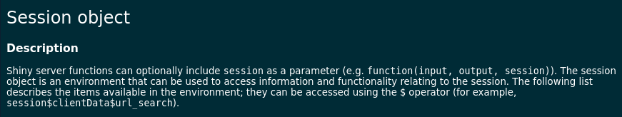

## Access control

Access information about the current user credentials

- User name
  - `session$user`
- User groups
  - `session$groups`
  - Vector of group names
- Use with `renderUI()`

Hard to experiment without deploying an application!

```r
server <- function(input, output, session) {
  output$superuser_ui <- renderUI({
    if (session$user == "superuser") {
      tagList(
        h2("Superuser UI!"),
        "God mode"
      )
    } else {
      NULL
    }
  })

  output$admin_ui <- renderUI({
    if ("admin" %in% session$groups) {
      tagList(
        h2("Admin UI!"),
        "Some fancy admin stuff"
      )
    } else {
      NULL
    }
  })
}
```

## `session$clientData`

Access information about the current client

- Access and manipulate URL
  - `getQueryString()`
  - `updateQueryString()`
  - `getUrlHash()`
- Client information
  - Other URL info
  - `pixelratio`

```r
server <- function(input, output, session) {
  output$query <- renderText({
    query <- getQueryString()

    query_text <- paste(names(query), query, sep = "=", collapse = ", ")
    paste("Query string values are:\n", query_text)
  })

  observe({
    updateQueryString(input$query_text, mode = "push")
  }) |>
    bindEvent(input$update_query)

  output$pixelratio <- renderText({
    session$clientData$pixelratio
  })
}
```

## `session$userData`

Access and store our own information about the user session

- An environment to store arbitrary data
  - Accessible across the session
  - This is *not reactive*
- Use cases
  - Package development
  - Modules

```r
server <- function(input, output, session) {
  observe({
    session$userData$my_variable <- input$my_variable_text
  })

  output$my_variable <- renderText({
    input$print_my_variable

    session$userData$my_variable
  })
}
```

# Bookmarking

📝 session_04/bookmarking_url.R

📝 session_04/bookmarking_server.R

## Restoring application state

Bookmarking allows you to save the state of the application, and return the application to this state with a special URL

- Preset the values of inputs
- The reactive graph is *replayed* as if the user set these inputs
- Two methods of bookmarking - `"url"` and `"server"`

**Encoded state - `"url"`**

The state of the application is stored in the query string

**Saved state - `"server"`**

The state of the application is saved to disk on the server

## Enabling bookmarking

Single file applications

- `shinyApp()`
- `enableBookmarking` argument

```
app.R
```

```r
ui <- fixedPage()

server <- function(input, output, session) { }

shinyApp(ui, server, enableBookmarking = "url")
```

Multi-file applications

- `enableBookmarking()`
- global.R

```
ui.R
```

```r
ui <- fixedPage()
```

```
server.R
```

```r
server <- function(input, output, session) { }
```

```
global.R
```

```r
enableBookmarking("url")
```

## Bookmark button

Pre-defined button that produces a bookmark URL for the current application state

- Enable bookmarking
- Convert UI to a function taking a `request` argument
- Add a `bookmarkButton()`

```r
library(shiny)

ui <- function(request) {
  fluidPage(
    textInput("my_text", "Write some text here"),
    checkboxInput("my_checkbox", "Check me"),
    bookmarkButton()
  )
}

server <- function(input, output, session) { }

shinyApp(ui, server, enableBookmarking = "url")
```

See the help page for more details!

# Wrapping up

## Homework - Readings

### Mastering Shiny

**[Chapter 13-16: Mastering reactivity](https://mastering-shiny.org/reactivity-intro.html)**

**[Chapter 11: Bookmarking](https://mastering-shiny.org/action-bookmark.html)**

### Shiny articles

**[Debugging Shiny applications](https://shiny.rstudio.com/articles/debugging.html)**

**[Bookmarking](https://shiny.rstudio.com/articles/#bookmarking)**

**[Learn about your user with session$clientData](https://shiny.rstudio.com/articles/client-data.html)**

## Homework - Exercise

Continue with your shiny application from session 3

- Explore reactivity
  - Use reactlog
  - Investigate what happens in the reactive graph as you interact with your application
- Experiment with our new reactive components
- Use the session object
  - Create some `userData`
- Enable bookmarking
  - Try both `"url"` and `"server"`
  - How are they different?

## Goodbye!

### Next Session

5. *Shiny modules, working with data*

**Introduction to Shiny** Session 4: *Reactivity and the user session*